# RNAseq_Assign

# Using the TXI object to summarize the kallisto transcript quantification to the gene-level.

```r
txi = tximport(files, type = "kallisto", tx2gene = tx2gene)
```

```
## Note: importing `abundance.h5` is typically faster than `abundance.tsv`
```

```
## reading in files with read_tsv
```

```
## 1 2 3 4 5 6
## removing duplicated transcript rows from tx2gene
## transcripts missing from tx2gene: 4852
## summarizing abundance
## summarizing counts
## summarizing length
```

```r
head(txi$abundance)
```

```
##          control_1    control_2    control_3     tumour_1     tumour_2
##       7032.9440367 7410.7723575 7.136402e+03 7.102417e+03 7174.6054317
## A1BG     5.7645150    4.4543900 6.945454e+00 5.826272e+00    6.6909090
## A1CF     0.0211616    0.0000000 8.789296e-02 1.421432e-02    0.0352926
## A2M    119.7816420  103.0222130 1.131782e+02 1.002309e+02   91.3623100
## A2ML1    0.2314672    0.0266311 8.024680e-02 4.832294e-01    0.2613149
## A2MP1    0.5810670    0.6913360 5.689230e-01 8.482020e-01    0.6641670
##           tumour_3
##       5997.5194101
## A1BG     3.9743940
## A1CF     0.0208836
## A2M    113.4002800
## A2ML1    0.5268268
## A2MP1    0.8663080
```

# DEseq2

# Creating the DDS object for DEseq analysis that contains the metadata and helps form the model design for analysis. This specifies the colums of the metadata file and compares the control to the tumour data in the experiment.

```r
dds <- DESeqDataSetFromTximport(txi, colData = samples, design = ~ replicate + condition )
```

```
## using counts and average transcript lengths from tximport
```

# Adjusting the reference level to control in order to compare tumour vs control.

```r
dds$condition <- relevel(dds$condition, ref = "control")
dds <- DESeq(dds)
```

```
## using 'avgTxLength' from assays(dds), correcting for library size
```

```r
resultsNames(dds)
```

```
## [1] "Intercept"                   "replicate_2_vs_1"
## [3] "replicate_3_vs_1"            "condition_tumour_vs_control"
```

# Quality Control

# Use the gene-level counts to perform some quality control checks on the samples in the experiment in order to reduce the lowly-expressed genes on the analysis (to increase sensitivity and precision of the Differentially expressed genes).

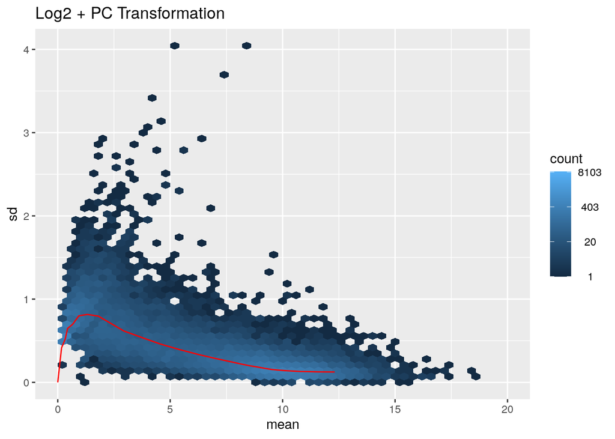

```r
counts <- counts(dds, normalized=TRUE)

# Looking into the Log2 and PC transformation of the transformed mean with the standard deviation
log2_counts <- assay(normTransform(dds))
rld_counts <- assay(rlog(dds))

library(vsn)
library(hexbin)

log2_plt <- meanSdPlot(log2_counts, ranks=FALSE, plot=FALSE)
log2_plt$gg + ggtitle("Log2 + PC Transformation") + xlim(0,20)
```

# Plotting the Rlog transformation of the transformed mean and the standard deviation.

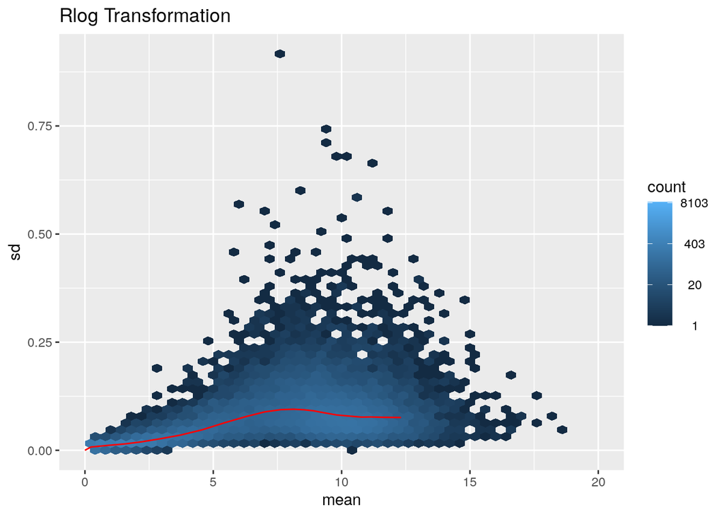

```r
rld_plt <- meanSdPlot(rld_counts, ranks=FALSE, plot=FALSE)
rld_plt$gg + ggtitle("Rlog Transformation") + xlim(0,20)
```

# Save Counts

# Created .txt files and moved to the data folder to then run and implement the information of gene level counts in the files.

```r
write.table(counts, "/home/rstudio/rstudio/data/normalised_counts.txt", sep="\t", quote = F)
write.table(log2_counts, "/home/rstudio/rstudio/data/log2_counts.txt", sep="\t", quote = F)
```

# Sample Heatmap distances matrix

# Overview of the similarities and differences of the two samples

# The color spectrum shows the number of differences between the two data samples for example, tumour_3 is very different than control_1, but control_2 is more similar to control_3.

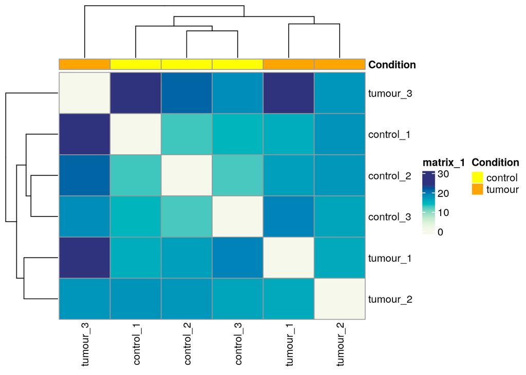

```r
# Calculate distance between samples
sampleDists = dist(t(rld_counts))

# Place distances in matrix
sampleDistMatrix = as.matrix(sampleDists)

# create annotation dataframe
ann = data.frame(Condition = samples$condition)

col = c("orange", "yellow")
names(col) = c("tumour", "control")
ann_col = list(Condition = col)

# match annotation rownames to distance mat
rownames(ann) = rownames(sampleDistMatrix)

pheatmap(mat=sampleDistMatrix,
         # pass distance metric calculated to heatmap
         clustering_distance_rows=sampleDists,
         clustering_distance_cols=sampleDists,
         # pass annotation dataframe
         annotation_col = ann,
         # add colors
         annotation_colors = ann_col,
         # heatmap colours
         col=hcl.colors(100,"GnBu",rev=T))
```